# Packages

```r
library(mdsr)
library(rpart)
library(nnet)
library(e1071)
library(randomForest)
library(ROCR)
library(plotROC)
library(ROCit)
```

# Init

```r
census <- read.csv(
  "http://archive.ics.uci.edu/ml/machine-learning-databases/adult/adult.data",
  header = FALSE)
names(census) <- c("age", "workclass", "fnlwgt", "education",
                   "education.num", "marital.status", "occupation",
                   "relationship", "race", "sex", "capital.gain",
                   "capital.loss", "hours.per.week", "native.country",
                   "income")
set.seed(364)
n <- nrow(census)
test_idx <- sample.int(n, size = round(0.2 * n))
train <- census[-test_idx,]
test <- census[test_idx,]

form <- as.formula("income ~ age + workclass + education + marital.status +
  occupation + relationship + race + sex + capital.gain + capital.loss +
  hours.per.week")

cut_seq <- seq(0, 1, 0.1)
cut_seq_2 <- seq(0, 1, 0.25)
```

# Models

## Decision Tree

```r
mod_tree <- rpart(form, data = train)
income_tree_probs <- mod_tree %>% predict(newdata = test, type = "prob")
df_tree <- data.frame(predictions = income_tree_probs[, ' >50K'],
                      labels = ifelse(test$income == ' >50K', 1, 0))
```

## Naive Bayes

```r
mod_nb <- naiveBayes(form, data = train)
income_nb_probs <- mod_nb %>% predict(newdata = test, type = "raw")
df_nb <- data.frame(predictions = income_nb_probs[, ' >50K'],
                    labels = ifelse(test$income == ' >50K', 1, 0))
```

## Neural Network

```r
mod_nn <- nnet(form, data = train, size = 5)
income_nn_probs <- mod_nn %>% predict(newdata = test, type = "raw")
df_nn <- data.frame(predictions = income_nn_probs,
                    labels = ifelse(test$income == ' >50K', 1, 0))
```

## Random Forest

```r
mod_forest <- randomForest(form, data = train, ntree = 201, mtry = 3)
income_forest_probs <- mod_forest %>% predict(newdata = test, type = "prob")
df_forest <- data.frame(predictions = income_forest_probs[, ' >50K'],
                        labels = ifelse(test$income == ' >50K', 1, 0))
```

# Comparing Packages

## ROCR

ROCR allows you to `colorize` a ROC curve according to threshold values. On top of that, you can also label a certain set of threshold values on the curve, giving you two different methods of identifying cutoffs.

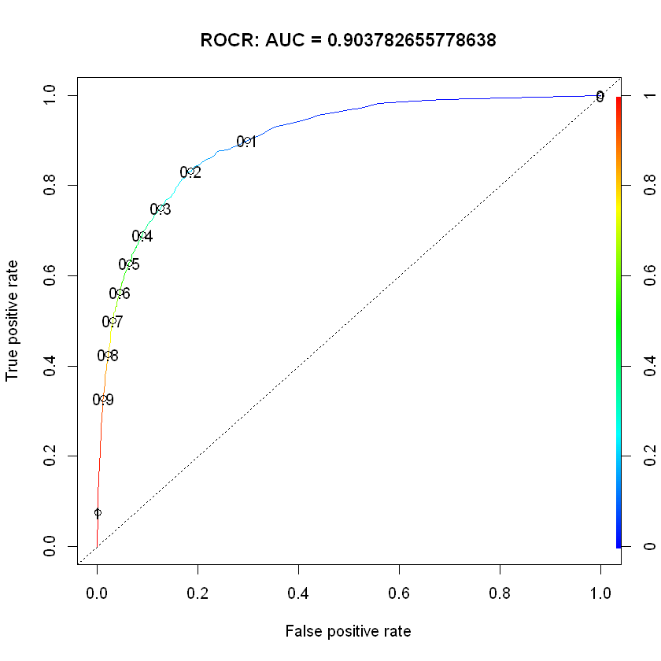

```r
rocr_pred_forest <- prediction(df_forest$predictions, df_forest$labels)
rocr_perf_forest <- performance(rocr_pred_forest, 'tpr', 'fpr')
rocr_perf_forest %>% plot(colorize = TRUE,
                          print.cutoffs.at = cut_seq)
rocr_auc_forest <- performance(rocr_pred_forest, 'auc')@y.values[[1]]
title(paste("ROCR: AUC =", rocr_auc_forest))
abline(0, 1, lty = 3)
```

Overlaying curves is actually fairly simple with `ROCR`. All you have to do is plot an initial curve, then every subsequent curve you plot must specify `add = TRUE`. This prevents the previous graph from going away. This, combined with `colorize`, provides an interesting way of comparing ROC curves and how their thresholds are distributed differently along them. The drawback of this approach is that there isn't an easy way to label or identify each line, other than remembering the shape of each one.

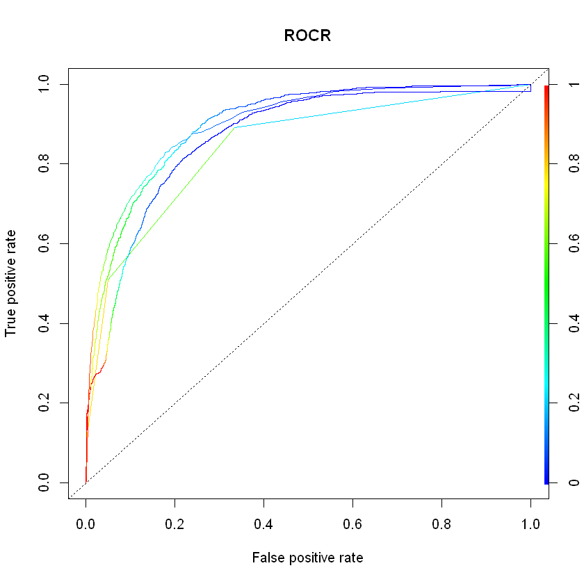

```r
rocr_pred_tree <- prediction(df_tree$predictions, df_tree$labels)
rocr_pred_nb <- prediction(df_nb$predictions, df_nb$labels)
rocr_pred_nn <- prediction(df_nn$predictions, df_nn$labels)

rocr_perf_tree <- performance(rocr_pred_tree, 'tpr', 'fpr')
rocr_perf_nb <- performance(rocr_pred_nb, 'tpr', 'fpr')
rocr_perf_nn <- performance(rocr_pred_nn, 'tpr', 'fpr')

rocr_perf_forest %>% plot(colorize = TRUE)
rocr_perf_tree %>% plot(colorize = TRUE, add = TRUE)
rocr_perf_nb %>% plot(colorize = TRUE, add = TRUE)
rocr_perf_nn %>% plot(colorize = TRUE, add = TRUE)
abline(0, 1, lty = 3)
title("ROCR")
```

We can emulate the same idea as before but with identifiers for each curve. We lose the gradients in exchange for color identifiers and substitute in labels to identify threshold locations. The labels are all black, so it is easy to confuse nearby labels.

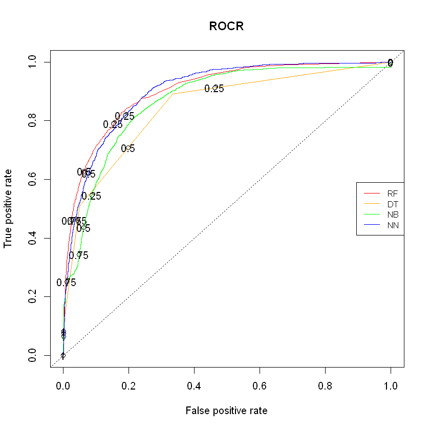

```r
rocr_perf_forest %>% plot(print.cutoffs.at = cut_seq_2,
                          col = "red")
rocr_perf_tree %>% plot(print.cutoffs.at = cut_seq_2,
                        col = "orange", add = TRUE)
rocr_perf_nb %>% plot(print.cutoffs.at = cut_seq_2,
                      col = "green", add = TRUE)
rocr_perf_nn %>% plot(print.cutoffs.at = cut_seq_2,
                      col = "blue", add = TRUE)
abline(0, 1, lty = 3)
legend("right", legend = c("RF", "DT", "NB", "NN"),
       col = c("red", "orange", "green", "blue"),
       lty = 1, cex = 0.8)
title("ROCR")
```

## plotROC

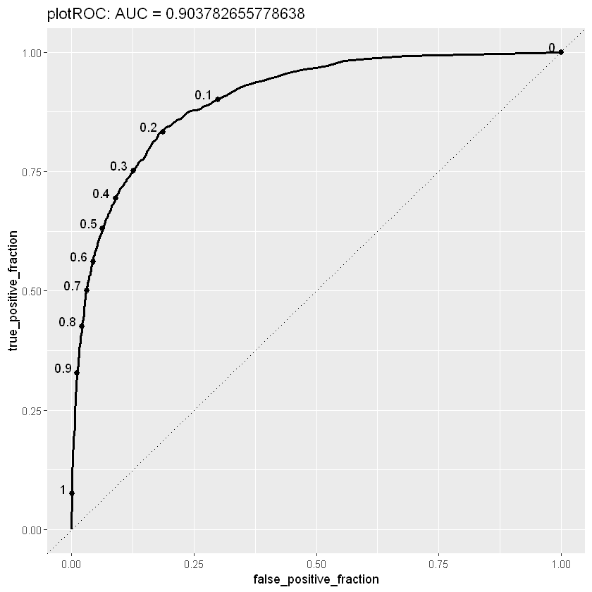

```r
plotroc_plot <- df_forest %>% ggplot(aes(m = predictions, d = labels)) +
  geom_roc(cutoffs.at = cut_seq) +
  geom_abline(slope = 1, intercept = 0, lty = 3)
plotroc_auc <- calc_auc(plotroc_plot)[['AUC']]
plotroc_ggplot <- plotroc_plot +
  ggtitle(paste("plotROC: AUC =", plotroc_auc))
plotroc_ggplot
```

Overlaying multiple curves is fairly simple. All you have to do is combine them all into one data frame and give them an identifier by model, then separate them by color on the plot. The labels are colored according to which model they belong to, making this graph easier to interpret and nicer to look at than the similar `ROCR` overlay.

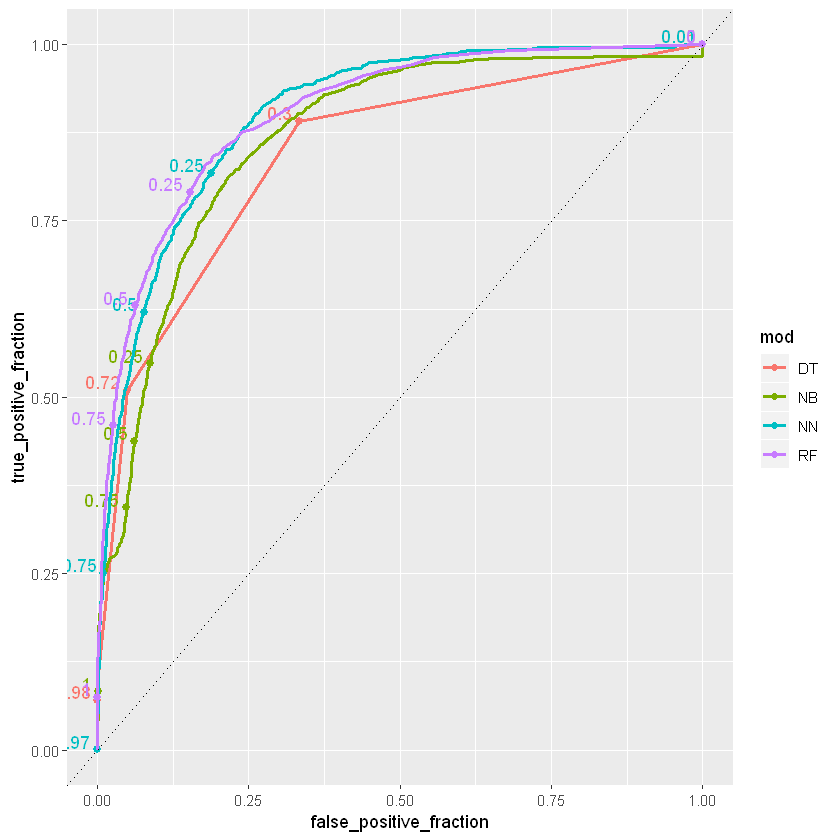

```r
df_all <- rbind(mutate(df_forest, mod = "RF"),
               mutate(df_tree, mod = "DT"),
               mutate(df_nb, mod = "NB"),
               mutate(df_nn, mod = "NN"))
df_all %>% ggplot(aes(m = predictions, d = labels, color = mod)) +
  geom_roc(cutoffs.at = cut_seq_2, labelround = 2) +
  geom_abline(slope = 1, intercept = 0, lty = 3)
```

## ROCit

`ROCit` is interesting because, by default, it plots an "Optimal (Youden Index) point" for each curve, which is the point on the curve that is the farthest from the Chance line vertically. This gives a useful but perhaps loose benchmark for optimality. The `rocit_plot` also silently has all the fpr, tpr, and cutoff values, but does not display the cutoff values at all.

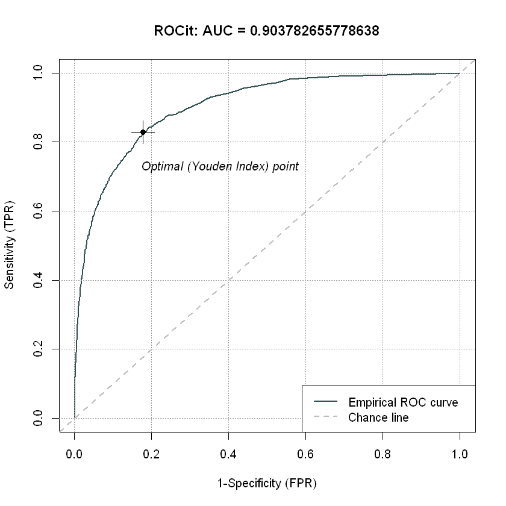

```r
rocit_obj <- rocit(df_forest$predictions, df_forest$labels)
rocit_plot <- rocit_obj %>% plot()
rocit_auc <- rocit_obj[['AUC']]
title(paste("ROCit: AUC =", rocit_auc))
```

## ROCit and ROCR Combined

If you want the nice look of a `ROCit` plot with the labelling provided by `ROCR`, you can combine the two in the same way we combined the multiple `ROCR` plots from before, by specifying `add = TRUE`.

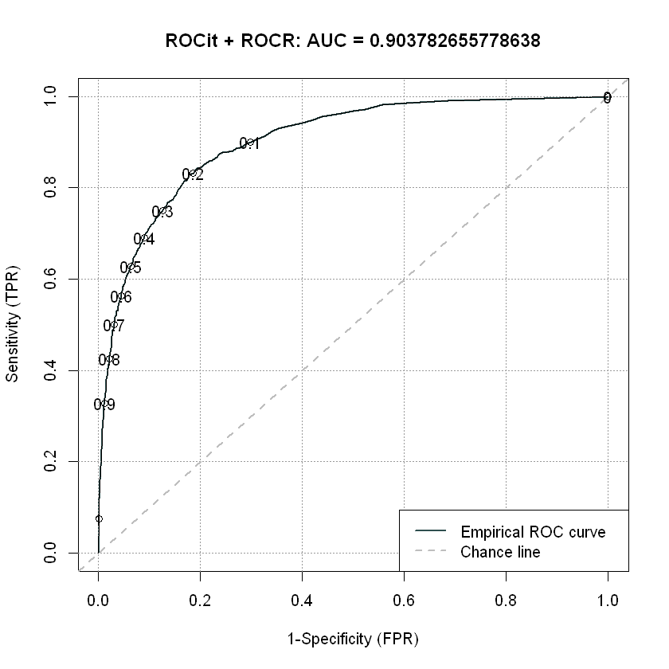

```r
rocit_obj %>% plot(YIndex = FALSE)
rocr_perf_forest %>% plot(print.cutoffs.at = cut_seq, add = TRUE)
title(paste("ROCit + ROCR: AUC =", rocit_auc))
```